# Modelo Regresión Objetivo 3

Joel Porcar

2025-05-26

Carga de Datos

Se cargan los datos desde archivos locales. Por un lado, los precios horarios de la energía, y por otro, los flujos de importación y exportación de energía entre España y sus países vecinos.

```r
datosPrecio <- read.csv("C:/Users/joelp/OrdenadorJoelPorcar/Documentos/2nCienciadeDatos/Proyecto II/Joel Porcar/precios_energia.csv")
datosImpExp <- read.csv2("C:/Users/joelp/OrdenadorJoelPorcar/Documentos/2nCienciadeDatos/Proyecto II/Joel Porcar/datosImportacionExportacion20232024.csv",
                         header = FALSE, stringsAsFactors = FALSE)
```

Limpieza y Preparación de Datos

Se realiza una limpieza de los datos para eliminar columnas irrelevantes, ajustar nombres de variables, convertir fechas al formato correcto y separar correctamente los valores de importación y exportación de energía por país. Solo se considera el año 2024 para mantener un marco temporal reciente y coherente.

```r
# Limpieza inicial de datosImpExp
datosImpExp <- datosImpExp[, -c(1, 3, 4)]  # Eliminar columnas no necesarias
colnames(datosImpExp) <- as.character(unlist(datosImpExp[1, ]))
datosImpExp <- datosImpExp[-1, ]
datosImpExp <- datosImpExp[!grepl("programada P48", datosImpExp$name), ]

# Procesamiento de datosPrecio
colnames(datosPrecio)[colnames(datosPrecio) == "Precio....MWh."] <- "Precio"
datosPrecio <- datosPrecio %>%
  mutate(
    Fecha = as.Date(Fecha, format = "%d/%m/%Y"),
    Hora = as.numeric(Hora)
  ) %>%
  select(Fecha, Hora, Precio)

# Procesamiento de datosImpExp
datosImpExp <- datosImpExp %>%
  mutate(
    datetime = ymd_hms(datetime),
    Hora = as.numeric(substr(format(datetime, "%H:%M:%S"), 1, 2)),
    Fecha = as.Date(format(datetime, "%d/%m/%Y"), format = "%d/%m/%Y"),
    value = as.numeric(value),

    # Identificar país y tipo de operación
    pais = case_when(
      grepl("Francia", name) ~ "Francia",
      grepl("Marruecos", name) ~ "Marruecos",
      grepl("Portugal", name) ~ "Portugal",
      grepl("Andorra", name) ~ "Andorra",
      TRUE ~ "Otro"
    ),
    tipo = ifelse(grepl("Exportación", name), "Exportación", "Importación"),
    energia_MWh = value
  ) %>%
  filter(year(datetime) == 2024) %>%
  select(Fecha, Hora, pais, tipo, energia_MWh)
datosCompletos <- datosImpExp %>%
  left_join(datosPrecio, by = c("Fecha", "Hora"))
```

Análisis Inicial y Correlación

Aquí se reorganizan los datos para trabajar con el total diario de importaciones y exportaciones, junto al precio medio diario de la energía. Se calcula la correlación entre estas variables para identificar posibles relaciones lineales.

```r
datos_modelo <- datosCompletos %>%
  # Primero separamos importaciones y exportaciones
  pivot_wider(names_from = tipo, values_from = energia_MWh,
              values_fn = sum, values_fill = 0) %>%
  # Luego agrupamos por fecha y calculamos los promedios y sumas
  group_by(Fecha) %>%
  summarise(Precio_medio = mean(Precio, na.rm = TRUE),
            Importación = sum(Importación, na.rm = TRUE),
            Exportación = sum(Exportación, na.rm = TRUE))

# Ahora puedes calcular la correlación
cor(
  datos_modelo %>%
    select(-Fecha) %>%
    drop_na(),
  use = "complete.obs"
)
```

```
##              Precio_medio Importación Exportación
## Precio_medio    1.0000000   0.5946093   0.3459892
## Importación     0.5946093   1.0000000   0.4157126
## Exportación     0.3459892   0.4157126   1.0000000
```

Los resultados de correlación indican que el precio medio de la energía tiene una correlación positiva moderada con la importación de energía (0.59) y una correlación más baja con la exportación (0.35). Esto sugiere que el aumento en las importaciones puede estar relacionado con precios más altos.

Modelo Lineal

Se construye un modelo lineal que intenta predecir el precio medio diario de la energía utilizando como variables independientes la cantidad diaria de energía importada y exportada. Se imprime manualmente el resumen del modelo, omitiendo el R² ajustado.

```r
modelo_lineal <- lm(Precio_medio ~ Importación + Exportación, data=datos_modelo)
resumen <- summary(modelo_lineal)

# Imprimir la fórmula
cat("Call:\n")
```

```
## Call:
```

```r
print(modelo_lineal$call)
```

```
## lm(formula = Precio_medio ~ Importación + Exportación, data = datos_modelo)
```

```r
# Imprimir los residuos
cat("\nResiduals:\n")
```

```
##
## Residuals:
```

```r
print(summary(resumen$residuals))
```

```
##     Min.  1st Qu.   Median     Mean  3rd Qu.     Max.
## -76.9623 -24.1549   0.7622   0.0000  23.1956  82.7713
```

```r
# Imprimir coeficientes
cat("\nCoefficients:\n")
```

```
##
## Coefficients:
```

```r
print(coef(resumen))
```

```
##                 Estimate   Std. Error   t value     Pr(>|t|)
## (Intercept) 5.035708e+01 8.052368e+00  6.253698 1.127216e-09
## Importación 5.390115e-04 4.547228e-05 11.853628 1.272434e-27
## Exportación 2.505884e-04 9.645027e-05  2.598110 9.755589e-03
```

```r
# Imprimir estadísticas adicionales, excepto el R² ajustado
cat("\nResidual standard error:", resumen$sigma, "on", resumen$df[2], "degrees of freedom\n")
```

```
##
## Residual standard error: 30.76034 on 363 degrees of freedom
```

```r
cat("Multiple R-squared:", resumen$r.squared, "\n")
```

```
## Multiple R-squared: 0.3653616
```

```r
cat("F-statistic:", resumen$fstatistic[1], "on", resumen$fstatistic[2], "and", resumen$fstatistic[3], "DF, ",
    "p-value:", signif(pf(resumen$fstatistic[1], resumen$fstatistic[2], resumen$fstatistic[3], lower.tail = FALSE), 4), "\n")
```

```
## F-statistic: 104.4896 on 2 and 363 DF,  p-value: 1.441e-36
```

El modelo lineal es estadísticamente significativo, con un p-valor muy bajo que indica que las relaciones observadas entre las variables no son aleatorias. La importación tiene un coeficiente positivo considerable y altamente significativo, mientras que la exportación también tiene una influencia positiva pero menor. Aunque el modelo explica aproximadamente un 36% de la variabilidad en los precios, lo cual no es muy alto, sí muestra que ambas variables influyen en el precio. Esto puede indicar que factores adicionales externos también juegan un papel importante en la determinación del precio energético.

Visualización del Modelo

Se grafican las predicciones del modelo frente a los valores reales del precio de la energía a lo largo del tiempo, lo que permite visualizar el ajuste del modelo y cómo se comportan sus predicciones

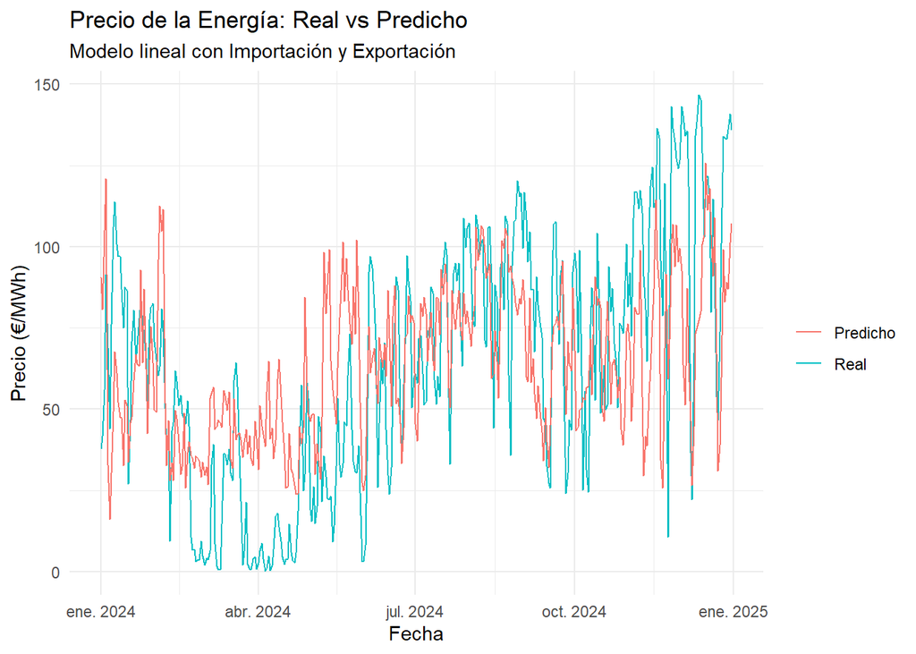

```r
datos_modelo$Pred_lineal <- predict(modelo_lineal)
ggplot(datos_modelo, aes(x=Fecha)) +
  geom_line(aes(y=Precio_medio, color="Real")) +
  geom_line(aes(y=Pred_lineal, color="Predicho")) +
  labs(title="Precio de la Energía: Real vs Predicho",
       subtitle="Modelo lineal con Importación y Exportación",
       y="Precio (€/MWh)", color="") +
  theme_minimal()
```

El gráfico muestra que el modelo logra capturar ciertas tendencias generales del precio de la energía, aunque no reproduce perfectamente todas las fluctuaciones. Las diferencias entre la línea real y la predicha indican que existen otros factores no incluidos en el modelo que influyen en el precio, como pueden ser la demanda interna, condiciones meteorológicas o políticas energéticas. Aun así, el modelo sirve como una base útil para poder imputar los datos en los años 2015, 2016, 2020 y 2022 y, al cruzarlos con la base de datos de datos reales de importación y exportación, poder sacar conclusiones válidas.